# Data 621 - Assignment 1

Dhairav Chhatbar

9/9/2020

```r
library(skimr)
library(ggplot2)
library(ggcorrplot)
library(dplyr)
library(tidyr)
library(PerformanceAnalytics)
library(DescTools)
library(cowplot)
```

```r
data_test <- read.csv("https://raw.githubusercontent.com/salma71/Data_621/master/HW_1/datasets/moneyball-evaluation-data.csv", header = TRUE)
data_train <- read.csv("https://raw.githubusercontent.com/salma71/Data_621/master/HW_1/datasets/moneyball-training-data.csv", header = TRUE)
```

## Data Exploration

1. Impute missing values
2. Combine/new variables
3. Transforms

Outliers & Leverage Points

In summary, an outlier is a point whose standardized residual falls outside the interval from –2 to 2. Recall that a bad leverage point is a leverage point which is also an outlier. Thus, a bad leverage point is a leverage point whose standar- dized residual falls outside the interval from –2 to 2. On the other hand, a good leverage point is a leverage point whose standardized residual falls inside the interval from –2 to 2.

Recall that the rule for simple linear regression for classifying a point as a leverage point is hii > 4/n .

## Select Models

```r
dim(data_train)
```

```
## [1] 2276   17
```

```r
# list types for each attribute
sapply(data_train, class)
```

```
##            INDEX      TARGET_WINS   TEAM_BATTING_H  TEAM_BATTING_2B
##        "integer"        "integer"        "integer"        "integer"
##  TEAM_BATTING_3B  TEAM_BATTING_HR  TEAM_BATTING_BB  TEAM_BATTING_SO
##        "integer"        "integer"        "integer"        "integer"
##  TEAM_BASERUN_SB  TEAM_BASERUN_CS TEAM_BATTING_HBP  TEAM_PITCHING_H
##        "integer"        "integer"        "integer"        "integer"
## TEAM_PITCHING_HR TEAM_PITCHING_BB TEAM_PITCHING_SO  TEAM_FIELDING_E
##        "integer"        "integer"        "integer"        "integer"
## TEAM_FIELDING_DP
##        "integer"
```

```r
skim(data_train)
```

Data summary

| Name | data_train |
| --- | --- |
| Number of rows | 2276 |
| Number of columns | 17 |
| _______________________ |  |
| Column type frequency: |  |
| numeric | 17 |
| ________________________ |  |
| Group variables | None |

**Variable type: numeric**

| skim_variable | n_missing | complete_rate | mean | sd | p0 | p25 | p50 | p75 | p100 | hist |
| --- | --- | --- | --- | --- | --- | --- | --- | --- | --- | --- |
| INDEX | 0 | 1.00 | 1268.46 | 736.35 | 1 | 630.75 | 1270.5 | 1915.50 | 2535 | ▇▇▇▇▇ |
| TARGET_WINS | 0 | 1.00 | 80.79 | 15.75 | 0 | 71.00 | 82.0 | 92.00 | 146 | ▁▁▇▅▁ |
| TEAM_BATTING_H | 0 | 1.00 | 1469.27 | 144.59 | 891 | 1383.00 | 1454.0 | 1537.25 | 2554 | ▁▇▂▁▁ |
| TEAM_BATTING_2B | 0 | 1.00 | 241.25 | 46.80 | 69 | 208.00 | 238.0 | 273.00 | 458 | ▁▆▇▂▁ |
| TEAM_BATTING_3B | 0 | 1.00 | 55.25 | 27.94 | 0 | 34.00 | 47.0 | 72.00 | 223 | ▇▇▂▁▁ |
| TEAM_BATTING_HR | 0 | 1.00 | 99.61 | 60.55 | 0 | 42.00 | 102.0 | 147.00 | 264 | ▇▆▇▅▁ |
| TEAM_BATTING_BB | 0 | 1.00 | 501.56 | 122.67 | 0 | 451.00 | 512.0 | 580.00 | 878 | ▁▁▇▇▁ |
| TEAM_BATTING_SO | 102 | 0.96 | 735.61 | 248.53 | 0 | 548.00 | 750.0 | 930.00 | 1399 | ▁▆▇▇▁ |
| TEAM_BASERUN_SB | 131 | 0.94 | 124.76 | 87.79 | 0 | 66.00 | 101.0 | 156.00 | 697 | ▇▃▁▁▁ |
| TEAM_BASERUN_CS | 772 | 0.66 | 52.80 | 22.96 | 0 | 38.00 | 49.0 | 62.00 | 201 | ▃▇▁▁▁ |
| TEAM_BATTING_HBP | 2085 | 0.08 | 59.36 | 12.97 | 29 | 50.50 | 58.0 | 67.00 | 95 | ▂▇▇▅▁ |
| TEAM_PITCHING_H | 0 | 1.00 | 1779.21 | 1406.84 | 1137 | 1419.00 | 1518.0 | 1682.50 | 30132 | ▇▁▁▁▁ |
| TEAM_PITCHING_HR | 0 | 1.00 | 105.70 | 61.30 | 0 | 50.00 | 107.0 | 150.00 | 343 | ▇▇▆▁▁ |
| TEAM_PITCHING_BB | 0 | 1.00 | 553.01 | 166.36 | 0 | 476.00 | 536.5 | 611.00 | 3645 | ▇▁▁▁▁ |
| TEAM_PITCHING_SO | 102 | 0.96 | 817.73 | 553.09 | 0 | 615.00 | 813.5 | 968.00 | 19278 | ▇▁▁▁▁ |
| TEAM_FIELDING_E | 0 | 1.00 | 246.48 | 227.77 | 65 | 127.00 | 159.0 | 249.25 | 1898 | ▇▁▁▁▁ |
| TEAM_FIELDING_DP | 286 | 0.87 | 146.39 | 26.23 | 52 | 131.00 | 149.0 | 164.00 | 228 | ▁▂▇▆▁ |

```r
library(kableExtra)
data_train %>%
  gather(variable, value) %>%
  filter(is.na(value)) %>%
  group_by(variable) %>%
  tally() %>%
  mutate(percent = n / nrow(data_train) * 100) %>%
  mutate(percent = paste0(round(percent, ifelse(percent < 10, 1, 0)), "%")) %>%
  arrange(desc(n)) %>%
  rename(`Variable Missing Data` = variable,
         `Number of Records` = n,
         `Share of Total` = percent) %>%
  kable() %>%
  kable_styling()
```

| Variable Missing Data | Number of Records | Share of Total |
| --- | --- | --- |
| TEAM_BATTING_HBP | 2085 | 92% |
| TEAM_BASERUN_CS | 772 | 34% |
| TEAM_FIELDING_DP | 286 | 13% |
| TEAM_BASERUN_SB | 131 | 5.8% |
| TEAM_BATTING_SO | 102 | 4.5% |
| TEAM_PITCHING_SO | 102 | 4.5% |

The hit by pitcher variable is missing over 90% of it’s data. We will exclude it from consideration in our model.

Caught stealling a base (TEAM_BASERUN_CS) is next on the list. It may be possible to predict it using TEAM_BASERUN_SB since they are strongly correlated, but there are 131 times they both are missing data.

MI: TRY - Drop variable if unlikely event in real life (HBP: hit by pitcher and CS: caught stealing base are rare) - Impute (try: mean, 0, drop)

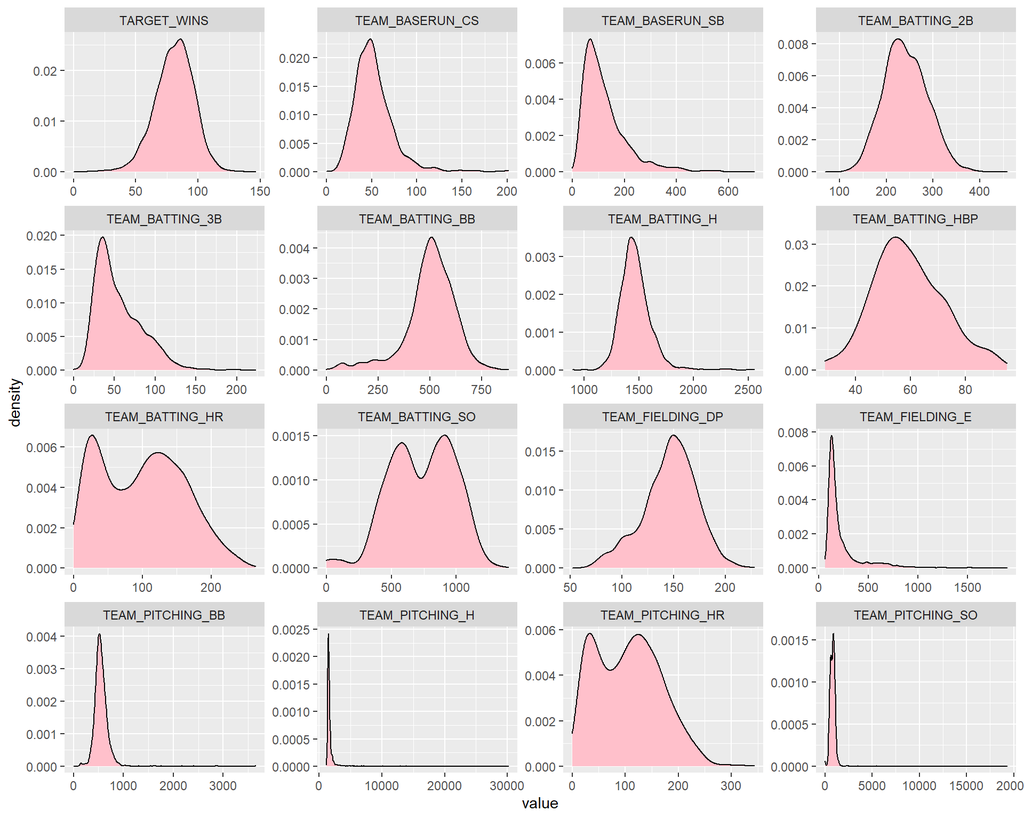

```r
#missing_per <- as.data.frame(t(data_train %>% select(everything()) %>% #summarise_all(funs(sum(is.na(.))))/nrow(data_train))) %>% arrange(desc(V1))
#missing_per
data_train %>%
  select(-INDEX) %>%
  gather() %>%
  ggplot( aes(x= value)) +
  geom_density(fill='pink') +
  facet_wrap(~key, scales = 'free')
```

Let’s take a closer look at the `TEAM_BASERUN_SB`

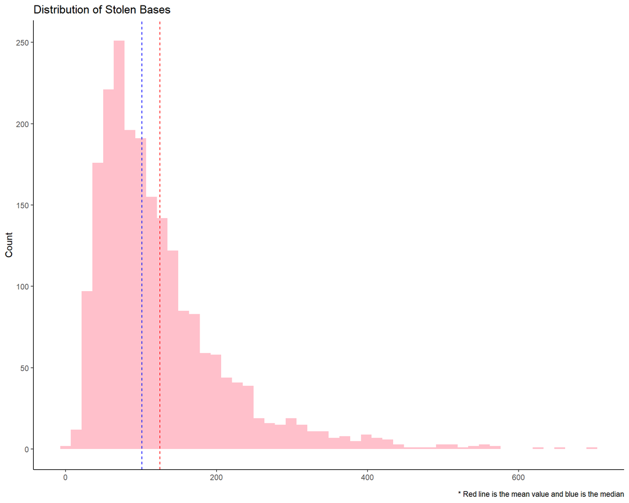

```r
data_train %>%
  ggplot(aes(TEAM_BASERUN_SB)) +
  geom_histogram(bins = 50, fill = 'pink') +
  geom_vline(aes(xintercept = mean(TEAM_BASERUN_SB, na.rm = T)), col = "red", lty = 2) +
  geom_vline(aes(xintercept = median(TEAM_BASERUN_SB, na.rm = T)), col = "blue", lty = 2) +
  labs(x = element_blank(),
       y = "Count",
       title = "Distribution of Stolen Bases",
       caption = "* Red line is the mean value and blue is the median") +
  theme_classic()
```

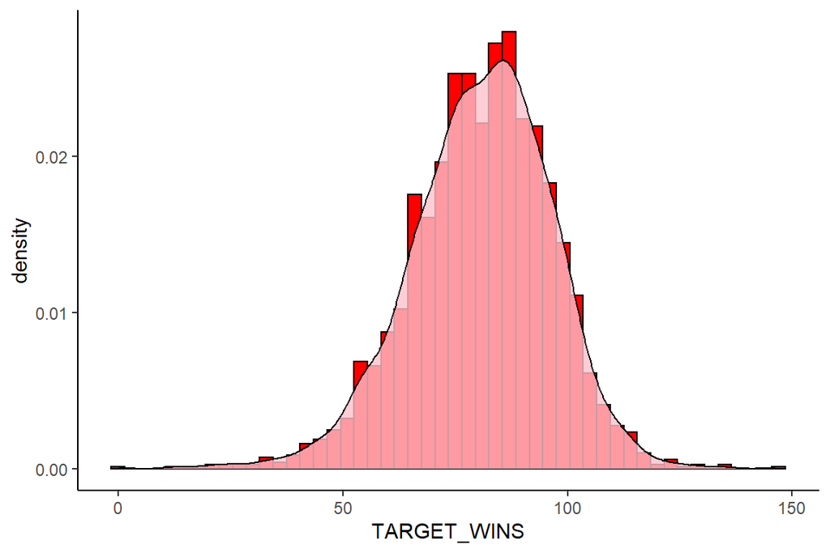

```r
ggplot(data_train, aes(x=TARGET_WINS)) +
    geom_histogram(aes(y=..density..),binwidth = 3, colour="black", fill="red") +
    geom_density(alpha=.8, fill="pink") +
  theme_classic()
```

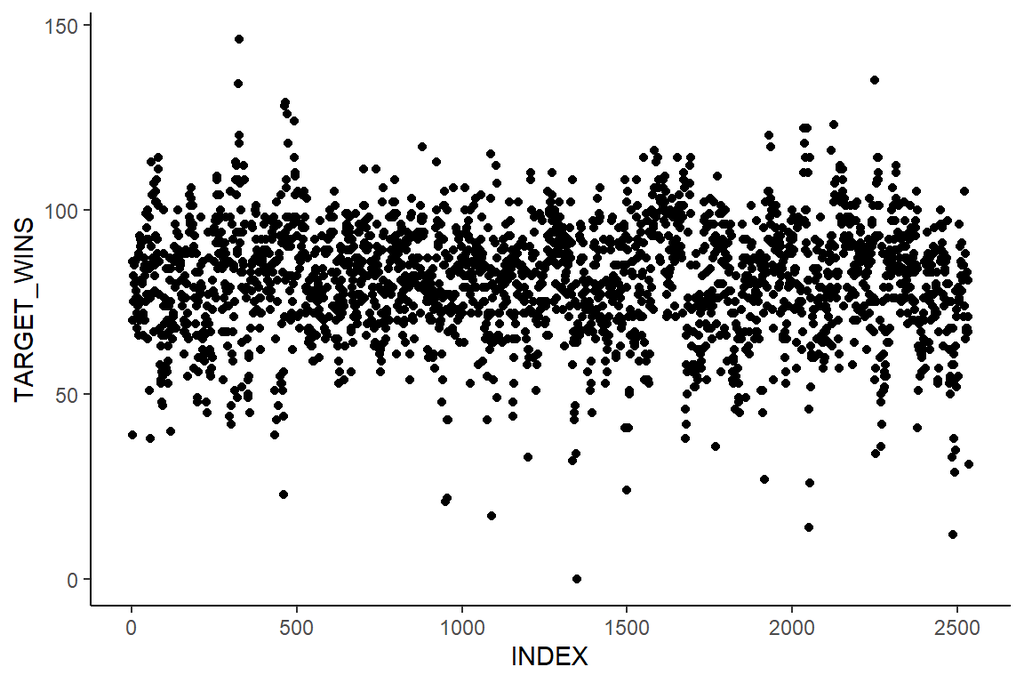

```r
ggplot(data_train, aes(x=INDEX, y=TARGET_WINS)) +
    geom_point(colour="black") +
    theme_classic()
```

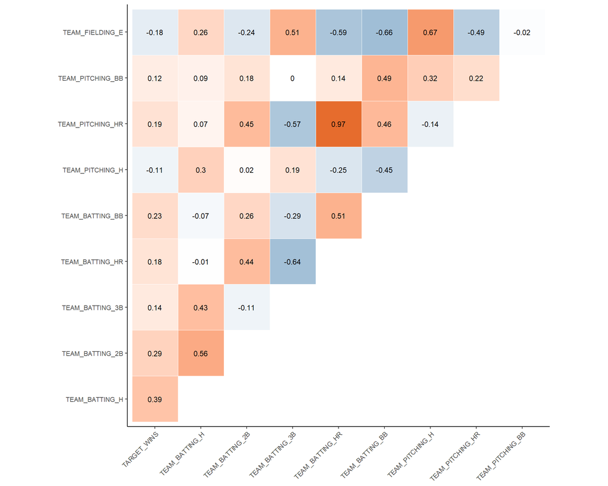

```r
to_plot <- data_train %>%
  dplyr::select(-INDEX)
q <- cor(to_plot)
ggcorrplot(q, type = "upper", outline.color = "white",
           ggtheme = theme_classic,
           colors = c("#6D9EC1", "white", "#E46726"),
           lab = TRUE, show.legend = FALSE, tl.cex = 8, lab_size = 3)
```

Correlations with Response Variable Let’s take a look at how the predictors are correlated with the response variable:

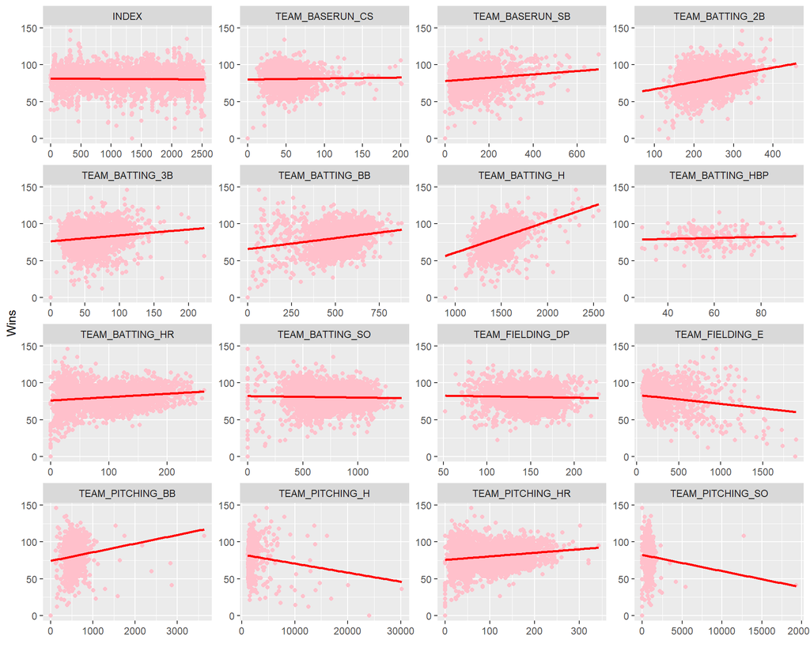

```r
data_train %>%
  gather(variable, value, -TARGET_WINS) %>%
  ggplot(., aes(value, TARGET_WINS)) +
  geom_point(fill = "pink", color="pink") +
  geom_smooth(method = "lm", se = FALSE, color = "red") +
  facet_wrap(~variable, scales ="free", ncol = 4) +
  labs(x = element_blank(), y = "Wins")
```

MI: - TEAM_PITCHING_HR (homeruns pitched) is slightly correlated win the number of wins. This is clearly unexpected because pitched homeruns are a negative for the pitching team. - TEAM_PITCHING_SO (strikeouts by pitcher) likely suffers from outliers because we’d expect strikeouts to be a positive thing for the pitching team. There is a large influential point. - TEAM_PITCHING_BB (walks allowed by pitcher) might suffer from outliers. We’d expected a negative correlation since a walk allowed is a negative for the pitching team.

### Data Prep

MI: - New variables: TEAM_BATTING_1B: TEAM_BATTING_H - SUM(TEAM_BATTING_i) where i = 2B,3B,HR - Transforms

```r
# New variable: TEAM_BATTING_1B
base_data <- select(data_train, -INDEX)
mod_data <- base_data %>% mutate(TEAM_BATTING_1B = base_data$TEAM_BATTING_H - select(., TEAM_BATTING_2B:TEAM_BATTING_HR) %>% rowSums(na.rm = FALSE))
head(mod_data)
```

```
##   TARGET_WINS TEAM_BATTING_H TEAM_BATTING_2B TEAM_BATTING_3B TEAM_BATTING_HR
## 1          39           1445             194              39              13
## 2          70           1339             219              22             190
## 3          86           1377             232              35             137
## 4          70           1387             209              38              96
## 5          82           1297             186              27             102
## 6          75           1279             200              36              92
##   TEAM_BATTING_BB TEAM_BATTING_SO TEAM_BASERUN_SB TEAM_BASERUN_CS
## 1             143             842              NA              NA
## 2             685            1075              37              28
## 3             602             917              46              27
## 4             451             922              43              30
## 5             472             920              49              39
## 6             443             973             107              59
##   TEAM_BATTING_HBP TEAM_PITCHING_H TEAM_PITCHING_HR TEAM_PITCHING_BB
## 1               NA            9364               84              927
## 2               NA            1347              191              689
## 3               NA            1377              137              602
## 4               NA            1396               97              454
## 5               NA            1297              102              472
## 6               NA            1279               92              443
##   TEAM_PITCHING_SO TEAM_FIELDING_E TEAM_FIELDING_DP TEAM_BATTING_1B
## 1             5456            1011               NA            1199
## 2             1082             193              155             908
## 3              917             175              153             973
## 4              928             164              156            1044
## 5              920             138              168             982
## 6              973             123              149             951
```

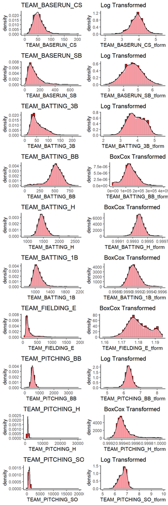

```r
# Data Transformations

data_transformed <- mod_data

#Log transform TEAM_BASERUN_CS
data_transformed$TEAM_BASERUN_CS_tform <-log(data_transformed$TEAM_BASERUN_CS)

baserun_cs <- ggplot(data_transformed, aes(x=TEAM_BASERUN_CS)) +
    geom_histogram(aes(y=..density..), colour="black", fill="red") +
    geom_density(alpha=.8, fill="pink") +
  theme_classic() + labs(title = "TEAM_BASERUN_CS")

baserun_cs_tf <- ggplot(data_transformed, aes(x=TEAM_BASERUN_CS_tform)) +
    geom_histogram(aes(y=..density..), colour="black", fill="red") +
    geom_density(alpha=.8, fill="pink") +
  theme_classic() + labs(title = "Log Transformed")

#Log transform TEAM_BASERUN_SB
data_transformed$TEAM_BASERUN_SB_tform <-log(data_transformed$TEAM_BASERUN_SB)

baserun_sb <- ggplot(data_transformed, aes(x=TEAM_BASERUN_SB)) +
    geom_histogram(aes(y=..density..), colour="black", fill="red") +
    geom_density(alpha=.8, fill="pink") +
  theme_classic() + labs(title = "TEAM_BASERUN_SB")

baserun_sb_tf <- ggplot(data_transformed, aes(x=TEAM_BASERUN_SB_tform)) +
    geom_histogram(aes(y=..density..), colour="black", fill="red") +
    geom_density(alpha=.8, fill="pink") +
  theme_classic() + labs(title = "Log Transformed")


#Log transform TEAM_BATTING_3B
data_transformed$TEAM_BATTING_3B_tform <-log(data_transformed$TEAM_BATTING_3B)

batting_3b <- ggplot(data_transformed, aes(x=TEAM_BATTING_3B)) +
    geom_histogram(aes(y=..density..), colour="black", fill="red") +
    geom_density(alpha=.8, fill="pink") +
  theme_classic() + labs(title = "TEAM_BATTING_3B")

batting_3b_tf <- ggplot(data_transformed, aes(x=TEAM_BATTING_3B_tform)) +
    geom_histogram(aes(y=..density..), colour="black", fill="red") +
    geom_density(alpha=.8, fill="pink") +
  theme_classic() + labs(title = "Log Transformed")

#BoxCoxtransform TEAM_BATTING_BB
data_transformed$TEAM_BATTING_BB_tform <- BoxCox(data_transformed$TEAM_BATTING_BB, BoxCoxLambda(data_transformed$TEAM_BATTING_BB))

batting_bb <- ggplot(data_transformed, aes(x=TEAM_BATTING_BB)) +
    geom_histogram(aes(y=..density..), colour="black", fill="red") +
    geom_density(alpha=.8, fill="pink") +
  theme_classic() + labs(title = "TEAM_BATTING_BB")

batting_bb_tf <- ggplot(data_transformed, aes(x=TEAM_BATTING_BB_tform)) +
    geom_histogram(aes(y=..density..), colour="black", fill="red") +
    geom_density(alpha=.8, fill="pink") +
  theme_classic() + labs(title = "BoxCox Transformed")


#BoxCoxtransform TEAM_BATTING_H
data_transformed$TEAM_BATTING_H_tform <- BoxCox(data_transformed$TEAM_BATTING_H, BoxCoxLambda(data_transformed$TEAM_BATTING_H))

batting_h <- ggplot(data_transformed, aes(x=TEAM_BATTING_H)) +
    geom_histogram(aes(y=..density..), colour="black", fill="red") +
    geom_density(alpha=.8, fill="pink") +
  theme_classic() + labs(title = "TEAM_BATTING_H")

batting_h_tf <- ggplot(data_transformed, aes(x=TEAM_BATTING_H_tform)) +
    geom_histogram(aes(y=..density..), colour="black", fill="red") +
    geom_density(alpha=.8, fill="pink") +
  theme_classic() + labs(title = "BoxCox Transformed")

#BoxCoxtransform TEAM_BATTING_1B
data_transformed$TEAM_BATTING_1B_tform <- BoxCox(data_transformed$TEAM_BATTING_1B, BoxCoxLambda(data_transformed$TEAM_BATTING_1B))

batting_1b <- ggplot(data_transformed, aes(x=TEAM_BATTING_1B)) +
    geom_histogram(aes(y=..density..), colour="black", fill="red") +
    geom_density(alpha=.8, fill="pink") +
  theme_classic() + labs(title = "TEAM_BATTING_1B")

batting_1b_tf <- ggplot(data_transformed, aes(x=TEAM_BATTING_1B_tform)) +
    geom_histogram(aes(y=..density..), colour="black", fill="red") +
    geom_density(alpha=.8, fill="pink") +
  theme_classic() + labs(title = "BoxCox Transformed")


#BoxCoxtransform TEAM_FIELDING_E
data_transformed$TEAM_FIELDING_E_tform <- BoxCox(data_transformed$TEAM_FIELDING_E, BoxCoxLambda(data_transformed$TEAM_FIELDING_E))

fielding_e <- ggplot(data_transformed, aes(x=TEAM_FIELDING_E)) +
    geom_histogram(aes(y=..density..), colour="black", fill="red") +
    geom_density(alpha=.8, fill="pink") +
  theme_classic() + labs(title = "TEAM_FIELDING_E")

fielding_e_tf <- ggplot(data_transformed, aes(x=TEAM_FIELDING_E_tform)) +
    geom_histogram(aes(y=..density..), colour="black", fill="red") +
    geom_density(alpha=.8, fill="pink") +
  theme_classic() + labs(title = "BoxCox Transformed")


#Log transform TEAM_PITCHING_BB
data_transformed$TEAM_PITCHING_BB_tform <-log(data_transformed$TEAM_PITCHING_BB)

pitching_bb <- ggplot(data_transformed, aes(x=TEAM_PITCHING_BB)) +
    geom_histogram(aes(y=..density..), colour="black", fill="red") +
    geom_density(alpha=.8, fill="pink") +
  theme_classic() + labs(title = "TEAM_PITCHING_BB")

pitching_bb_tf <- ggplot(data_transformed, aes(x=TEAM_PITCHING_BB_tform)) +
    geom_histogram(aes(y=..density..), colour="black", fill="red") +
    geom_density(alpha=.8, fill="pink") +
  theme_classic() + labs(title = "Log Transformed")


#BoxCoxtransform TEAM_PITCHING_H
data_transformed$TEAM_PITCHING_H_tform <- BoxCox(data_transformed$TEAM_PITCHING_H, BoxCoxLambda(data_transformed$TEAM_PITCHING_H))

pitching_h <- ggplot(data_transformed, aes(x=TEAM_PITCHING_H)) +
    geom_histogram(aes(y=..density..), colour="black", fill="red") +
    geom_density(alpha=.8, fill="pink") +
  theme_classic() + labs(title = "TEAM_PITCHING_H")

pitching_h_tf <- ggplot(data_transformed, aes(x=TEAM_PITCHING_H_tform)) +
    geom_histogram(aes(y=..density..), colour="black", fill="red") +
    geom_density(alpha=.8, fill="pink") +
  theme_classic() + labs(title = "BoxCox Transformed")


#Log transform TEAM_PITCHING_SO
data_transformed$TEAM_PITCHING_SO_tform <-log(data_transformed$TEAM_PITCHING_SO)

pitching_so <- ggplot(data_transformed, aes(x=TEAM_PITCHING_SO)) +
    geom_histogram(aes(y=..density..), colour="black", fill="red") +
    geom_density(alpha=.8, fill="pink") +
  theme_classic() + labs(title = "TEAM_PITCHING_SO")

pitching_so_tf <- ggplot(data_transformed, aes(x=TEAM_PITCHING_SO_tform)) +
    geom_histogram(aes(y=..density..), colour="black", fill="red") +
    geom_density(alpha=.8, fill="pink") +
  theme_classic() + labs(title = "Log Transformed")

plot_grid(baserun_cs, baserun_cs_tf, baserun_sb, baserun_sb_tf,
          batting_3b, batting_3b_tf, batting_bb, batting_bb_tf,
          batting_h, batting_h_tf, batting_1b, batting_1b_tf,
          fielding_e, fielding_e_tf, pitching_bb, pitching_bb_tf,
          pitching_h, pitching_h_tf, pitching_so, pitching_so_tf,
          ncol = 2)
```

### Build Models

```r
#data with all original variables
m1_data <- mod_data %>% select(-TEAM_BATTING_1B)

m1 <- lm(TARGET_WINS ~., data = m1_data)
summary(m1)
```

```
##
## Call:
## lm(formula = TARGET_WINS ~ ., data = m1_data)
##
## Residuals:
##      Min       1Q   Median       3Q      Max
## -19.8708  -5.6564  -0.0599   5.2545  22.9274
##
## Coefficients:
##                  Estimate Std. Error t value Pr(>|t|)
## (Intercept)      60.28826   19.67842   3.064  0.00253 **
## TEAM_BATTING_H    1.91348    2.76139   0.693  0.48927
## TEAM_BATTING_2B   0.02639    0.03029   0.871  0.38484
## TEAM_BATTING_3B  -0.10118    0.07751  -1.305  0.19348
## TEAM_BATTING_HR  -4.84371   10.50851  -0.461  0.64542
## TEAM_BATTING_BB  -4.45969    3.63624  -1.226  0.22167
## TEAM_BATTING_SO   0.34196    2.59876   0.132  0.89546
## TEAM_BASERUN_SB   0.03304    0.02867   1.152  0.25071
## TEAM_BASERUN_CS  -0.01104    0.07143  -0.155  0.87730
## TEAM_BATTING_HBP  0.08247    0.04960   1.663  0.09815 .
## TEAM_PITCHING_H  -1.89096    2.76095  -0.685  0.49432
## TEAM_PITCHING_HR  4.93043   10.50664   0.469  0.63946
## TEAM_PITCHING_BB  4.51089    3.63372   1.241  0.21612
## TEAM_PITCHING_SO -0.37364    2.59705  -0.144  0.88577
## TEAM_FIELDING_E  -0.17204    0.04140  -4.155 5.08e-05 ***
## TEAM_FIELDING_DP -0.10819    0.03654  -2.961  0.00349 **
## ---
## Signif. codes:  0 '***' 0.001 '**' 0.01 '*' 0.05 '.' 0.1 ' ' 1
##
## Residual standard error: 8.467 on 175 degrees of freedom
##   (2085 observations deleted due to missingness)
## Multiple R-squared:  0.5501, Adjusted R-squared:  0.5116
## F-statistic: 14.27 on 15 and 175 DF,  p-value: < 2.2e-16
```

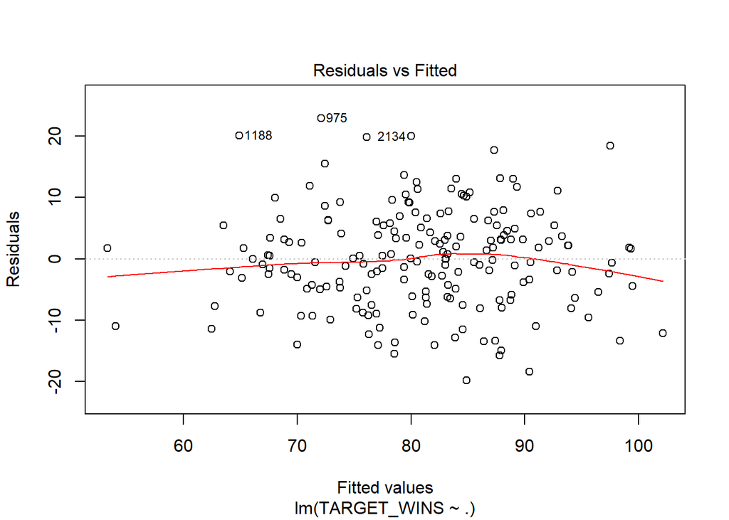

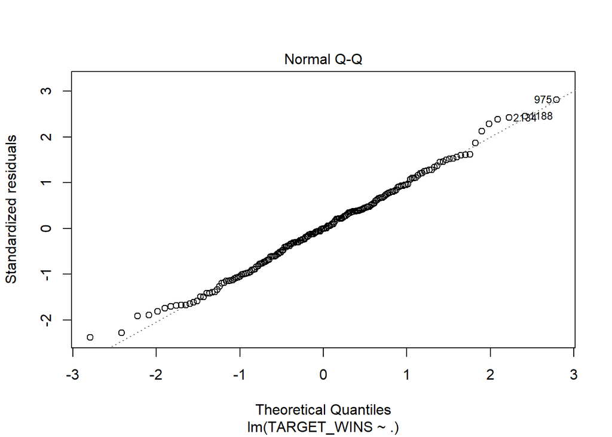

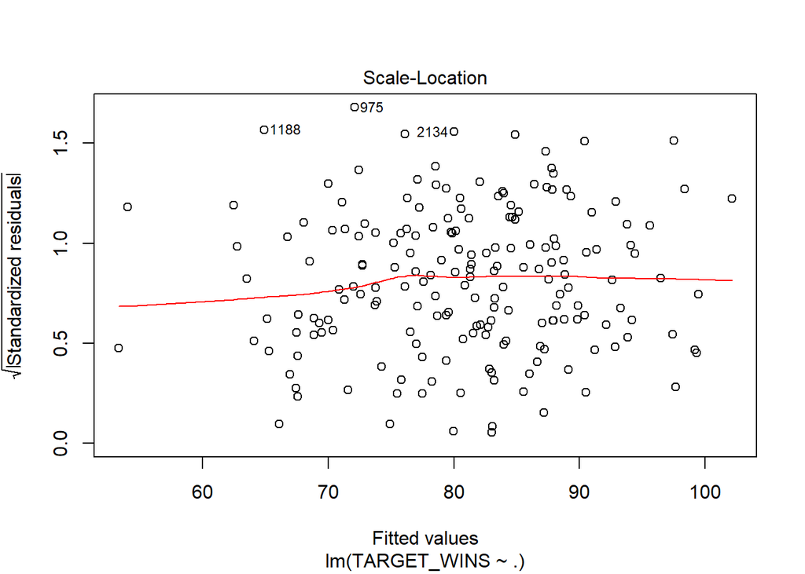

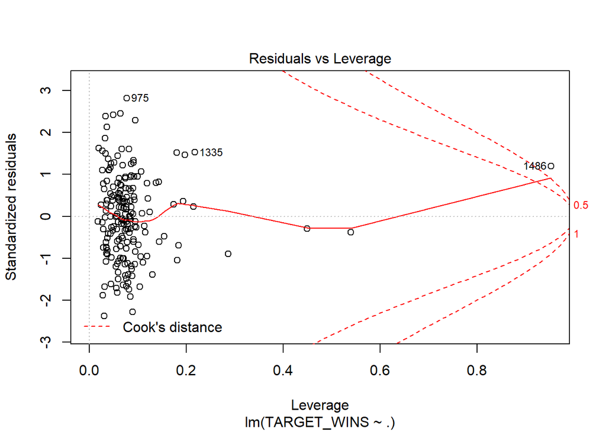

```r
plot(m1)
```

```r
#Issue: only 2 significant variables (fielding variables)
```

```r
#data without TEAM_BATTING_HBP, TEAM_BASERUN_CS, and TEAM_FIELDING_DP
m2_data <- mod_data %>% select(-TEAM_BATTING_HBP, -TEAM_BASERUN_CS, -TEAM_FIELDING_DP)

m2 <- lm(TARGET_WINS ~., data = m2_data)
summary(m2)
```

```
##
## Call:
## lm(formula = TARGET_WINS ~ ., data = m2_data)
##
## Residuals:
##     Min      1Q  Median      3Q     Max
## -44.960  -7.929   0.237   7.578  50.199
##
## Coefficients: (1 not defined because of singularities)
##                    Estimate Std. Error t value Pr(>|t|)
## (Intercept)      18.6512751  5.1545536   3.618 0.000304 ***
## TEAM_BATTING_H    0.0388959  0.0038004  10.235  < 2e-16 ***
## TEAM_BATTING_2B  -0.0475523  0.0090949  -5.228 1.88e-07 ***
## TEAM_BATTING_3B   0.0784471  0.0174928   4.485 7.72e-06 ***
## TEAM_BATTING_HR   0.0326904  0.0290518   1.125 0.260619
## TEAM_BATTING_BB   0.0279988  0.0066135   4.234 2.40e-05 ***
## TEAM_BATTING_SO  -0.0054466  0.0053050  -1.027 0.304695
## TEAM_BASERUN_SB   0.0588649  0.0042986  13.694  < 2e-16 ***
## TEAM_PITCHING_H   0.0024753  0.0004045   6.119 1.13e-09 ***
## TEAM_PITCHING_HR  0.0457063  0.0262823   1.739 0.082177 .
## TEAM_PITCHING_BB -0.0047439  0.0052439  -0.905 0.365764
## TEAM_PITCHING_SO -0.0066348  0.0047258  -1.404 0.160493
## TEAM_FIELDING_E  -0.0495831  0.0032314 -15.344  < 2e-16 ***
## TEAM_BATTING_1B          NA         NA      NA       NA
## ---
## Signif. codes:  0 '***' 0.001 '**' 0.01 '*' 0.05 '.' 0.1 ' ' 1
##
## Residual standard error: 11.62 on 2030 degrees of freedom
##   (233 observations deleted due to missingness)
## Multiple R-squared:  0.3621, Adjusted R-squared:  0.3583
## F-statistic: 96.01 on 12 and 2030 DF,  p-value: < 2.2e-16
```

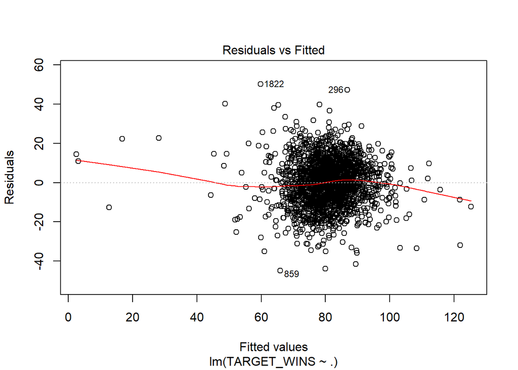

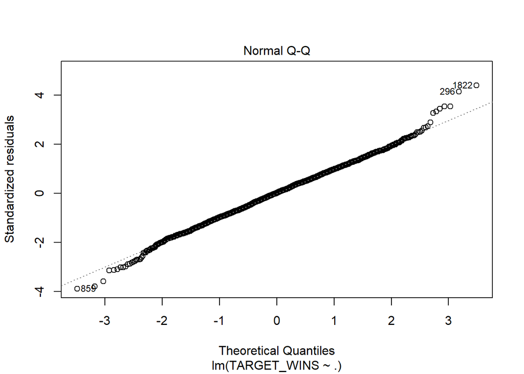

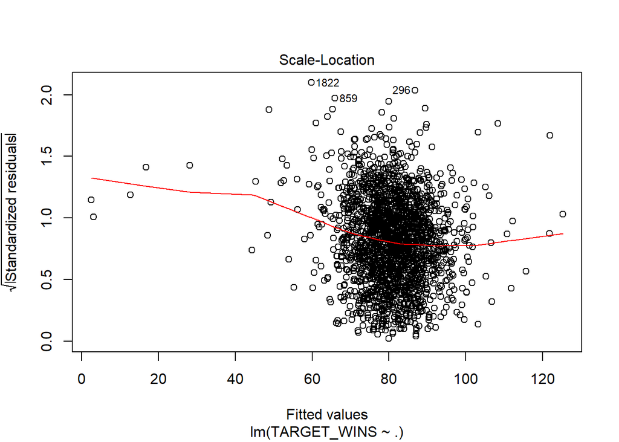

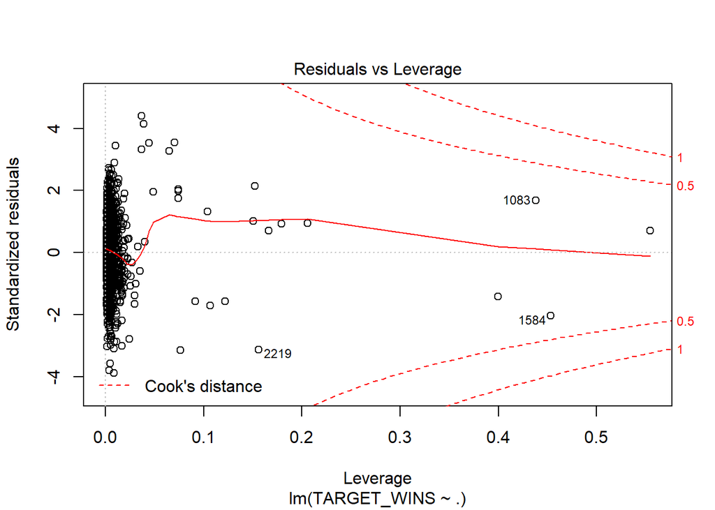

```r
plot(m2)
```

```r
#data without TEAM_BATTING_HBP, TEAM_BASERUN_CS, and TEAM_FIELDING_DP
m3_data <- mod_data %>% select(-TEAM_BATTING_HBP, -TEAM_BASERUN_CS, -TEAM_FIELDING_DP, -TEAM_BATTING_H)

m3 <- lm(TARGET_WINS ~., data = m3_data)
summary(m3)
```

```
##
## Call:
## lm(formula = TARGET_WINS ~ ., data = m3_data)
##
## Residuals:
##     Min      1Q  Median      3Q     Max
## -44.960  -7.929   0.237   7.578  50.199
##
## Coefficients:
##                    Estimate Std. Error t value Pr(>|t|)
## (Intercept)      18.6512751  5.1545536   3.618 0.000304 ***
## TEAM_BATTING_2B  -0.0086564  0.0071975  -1.203 0.229237
## TEAM_BATTING_3B   0.1173431  0.0166679   7.040 2.62e-12 ***
## TEAM_BATTING_HR   0.0715863  0.0291477   2.456 0.014133 *
## TEAM_BATTING_BB   0.0279988  0.0066135   4.234 2.40e-05 ***
## TEAM_BATTING_SO  -0.0054466  0.0053050  -1.027 0.304695
## TEAM_BASERUN_SB   0.0588649  0.0042986  13.694  < 2e-16 ***
## TEAM_PITCHING_H   0.0024753  0.0004045   6.119 1.13e-09 ***
## TEAM_PITCHING_HR  0.0457063  0.0262823   1.739 0.082177 .
## TEAM_PITCHING_BB -0.0047439  0.0052439  -0.905 0.365764
## TEAM_PITCHING_SO -0.0066348  0.0047258  -1.404 0.160493
## TEAM_FIELDING_E  -0.0495831  0.0032314 -15.344  < 2e-16 ***
## TEAM_BATTING_1B   0.0388959  0.0038004  10.235  < 2e-16 ***
## ---
## Signif. codes:  0 '***' 0.001 '**' 0.01 '*' 0.05 '.' 0.1 ' ' 1
##
## Residual standard error: 11.62 on 2030 degrees of freedom
##   (233 observations deleted due to missingness)
## Multiple R-squared:  0.3621, Adjusted R-squared:  0.3583
## F-statistic: 96.01 on 12 and 2030 DF,  p-value: < 2.2e-16
```

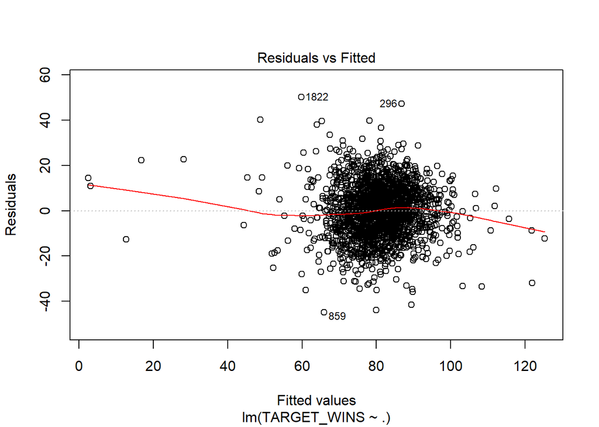

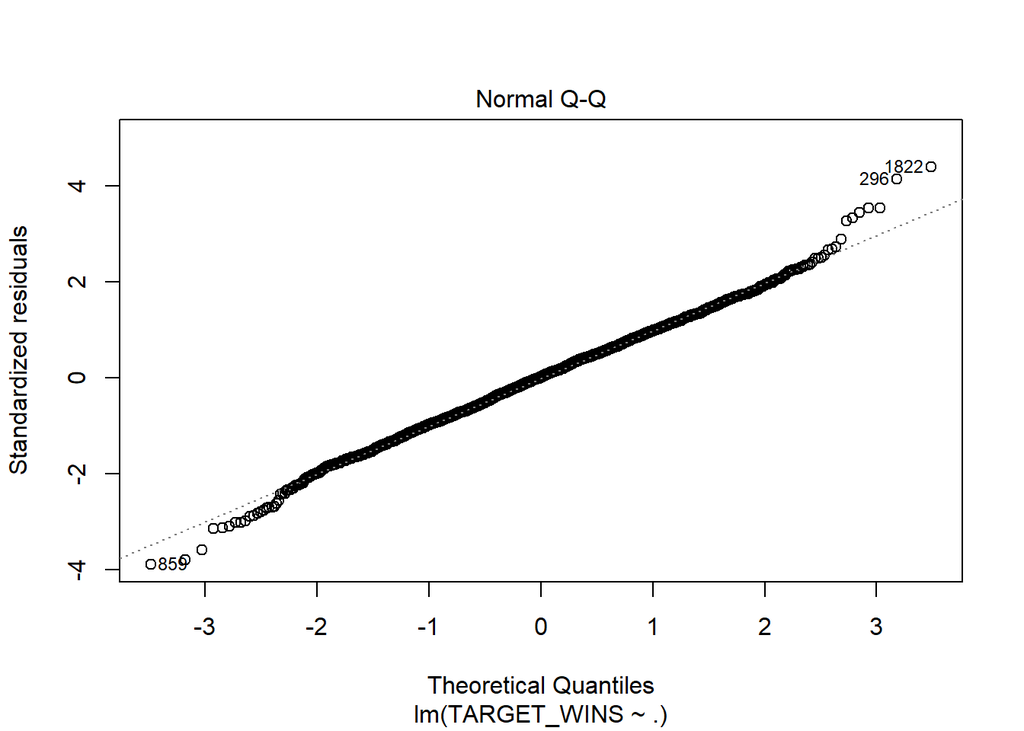

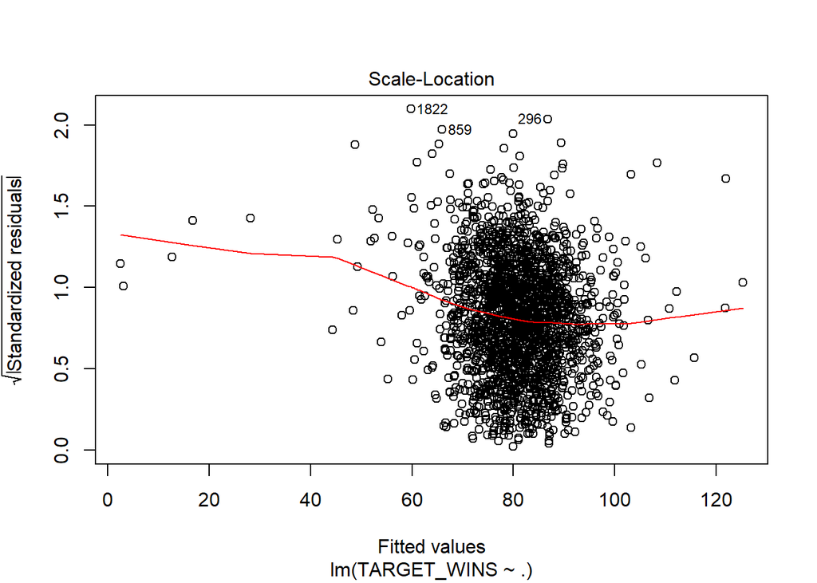

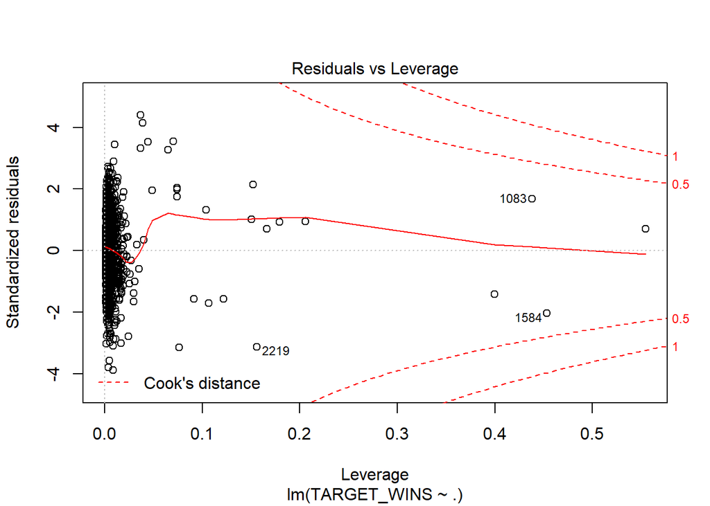

```r
plot(m3)
```

```r
#data with all transformed variables
m4_data <- select(data_transformed,-TEAM_BASERUN_CS, -TEAM_BASERUN_SB, -TEAM_BATTING_3B, -TEAM_BATTING_BB, -TEAM_BATTING_H, -TEAM_FIELDING_E, -TEAM_PITCHING_BB, -TEAM_PITCHING_H, -TEAM_PITCHING_SO, -TEAM_BATTING_HBP, -TEAM_BASERUN_CS, -TEAM_BATTING_1B)

m4 <- lm(TARGET_WINS ~., data = m4_data)
summary(m4)
```

```
##
## Call:
## lm(formula = TARGET_WINS ~ ., data = m4_data)
##
## Residuals:
##     Min      1Q  Median      3Q     Max
## -33.994  -6.794   0.131   6.903  31.095
##
## Coefficients:
##                          Estimate Std. Error t value Pr(>|t|)
## (Intercept)            -5.713e+04  3.049e+04  -1.873 0.061213 .
## TEAM_BATTING_2B        -5.845e-02  2.991e-02  -1.954 0.050836 .
## TEAM_BATTING_HR         8.265e-02  7.497e-02   1.102 0.270442
## TEAM_BATTING_SO        -3.289e-02  9.775e-03  -3.365 0.000786 ***
## TEAM_PITCHING_HR        2.690e-02  6.422e-02   0.419 0.675433
## TEAM_FIELDING_DP       -1.084e-01  1.343e-02  -8.069 1.46e-15 ***
## TEAM_BASERUN_CS_tform   9.830e-01  1.067e+00   0.921 0.356943
## TEAM_BASERUN_SB_tform   3.803e+00  8.515e-01   4.466 8.57e-06 ***
## TEAM_BATTING_3B_tform   6.310e+00  1.456e+00   4.335 1.56e-05 ***
## TEAM_BATTING_BB_tform   5.846e-05  2.713e-05   2.155 0.031329 *
## TEAM_BATTING_H_tform    8.573e+04  7.161e+04   1.197 0.231415
## TEAM_BATTING_1B_tform   1.446e+04  3.134e+04   0.462 0.644473
## TEAM_FIELDING_E_tform  -1.168e+03  9.249e+01 -12.630  < 2e-16 ***
## TEAM_PITCHING_BB_tform  4.444e+00  8.335e+00   0.533 0.594005
## TEAM_PITCHING_H_tform  -4.167e+04  2.492e+04  -1.672 0.094777 .
## TEAM_PITCHING_SO_tform  8.444e+00  7.733e+00   1.092 0.275075
## ---
## Signif. codes:  0 '***' 0.001 '**' 0.01 '*' 0.05 '.' 0.1 ' ' 1
##
## Residual standard error: 9.828 on 1470 degrees of freedom
##   (790 observations deleted due to missingness)
## Multiple R-squared:  0.4066, Adjusted R-squared:  0.4005
## F-statistic: 67.14 on 15 and 1470 DF,  p-value: < 2.2e-16
```

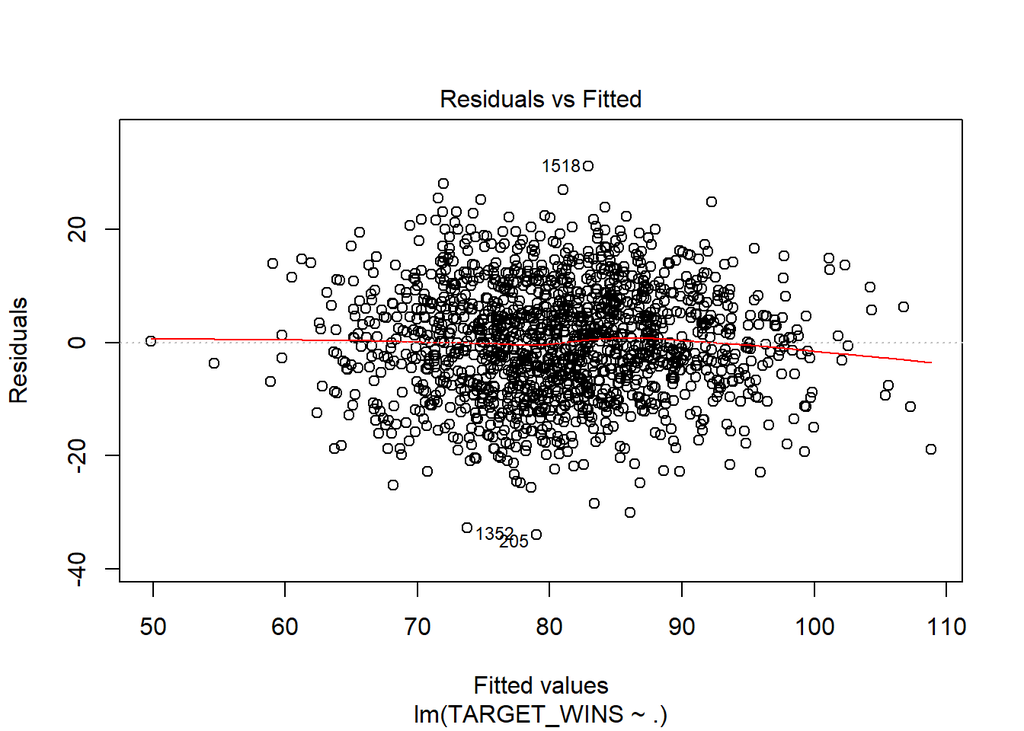

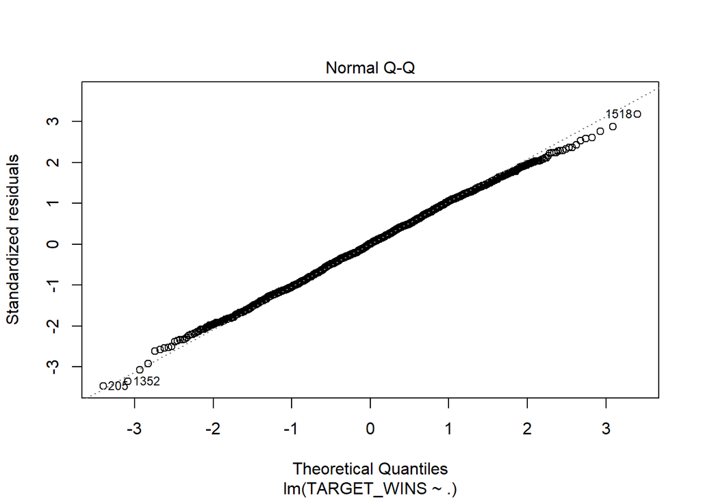

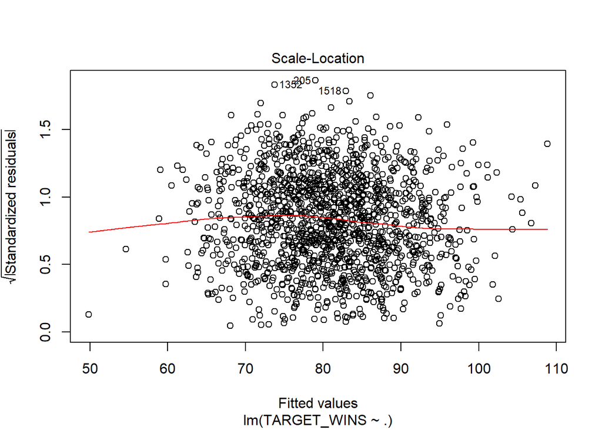

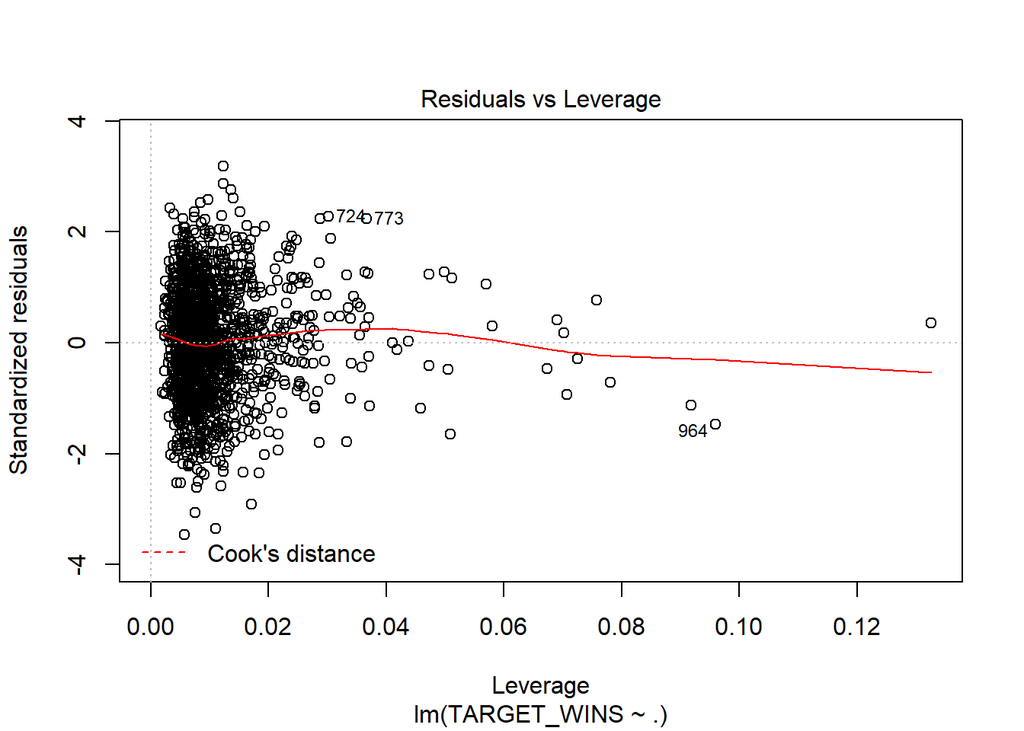

```r
plot(m4)
```